# Python_Dersleri

**PYTHON İLE PROGRAMLAMA**

> H.N. ÇETİNKAYA - Güncelleme: 21.11.2022

**İçindekiler**

# **Algoritma Nedir?**

**Algoritma,** belirli bir problemi çözmek veya belirli bir amaca ulaşmak için çözüm yolunun adım adım tasarlanmasıdır. Daha iyi anlamak için [Josh Darnit'in (2017) çocuklarıyla yaptığı 'Kesin Talimatlar' videosunu izleyebilirsiniz.](https://www.youtube.com/watch?v=FN2RM-CHkuI) Algoritmalar doğal dil (satır kod), sözde kod veya akış şeması ile ifade edilebilirler. Örnekler aşağıda verilmiştir.  
**Algoritma Yazım Örnekleri**

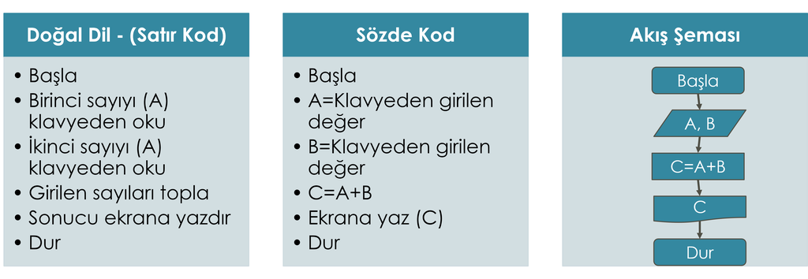

**Akış Şeması Örneği** (Torun, 2021)

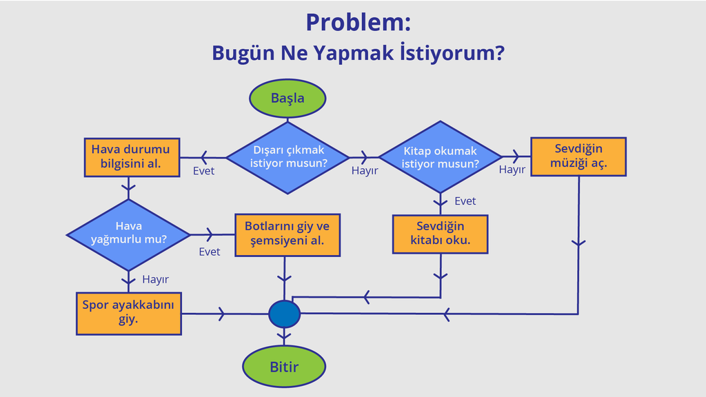

**Etkinlik:** Elinde kalem olan bir kişiye, yüzü duvara dönük veya gözü kapalı olan başka bir kişi hazırladığı algoritmik komutları dikdörtgen çizmesi (yazı tahtasına veya kağıda) için verir. Etkinlik roller değiştirilerek tekrarlanır.

## Algoritma Türleri

1. **Kaba Kuvvet Algoritması:** Bir problemi çözmek için en basit yaklaşımdır. Kaba kuvvet algoritması, çözümü bulmak için tüm yolları denemektir. Uzun süren bir yöntemdir.
2. **Geri İzleme Algoritması:** Geri izleme algoritması temel olarak çözüme giden küçük adımlarla çözümü aramaktır. Bu algoritmada bir adım başarısız olduğunda hata olan adıma geri döneriz ve yeni bir yol oluştururuz. Problem çözülene kadar bu işleme devam ederiz.
3. **Özyinelemeli Algoritma:** Özyinelemeli bir algoritma işlemleri tekrarlamayı temel alır. Bu algoritmada, bir problem onu oluşturan en küçük örüntü parçasına bölünür ve örüntüsel olarak problemi çözmesi beklenen işlemler tekrar tekrar yapılır. Küçük parçalara bölerken ana problemin çözümü ile aynı örüntüye göre bölünmesi esastır.
4. **Arama Algoritmaları:** Arama algoritmaları, veri yapılarındaki (metin, sayı, grafik vb.) elemanları veya eleman gruplarını aramak için kullanılan genel yaklaşımlardır. Birçok yaklaşım vardır. Genel olarak 'bilmeden arama' ve 'bilerek arama' olarak gruplandırılırlar (Evren, 2009)
   - Doğrusal Arama
   - İkili Arama
   - Enine Arama
   - Derin Arama
   - Ve diğerleri...
5. **Sıralama Algoritmaları:** Sıralama, bir grup verinin ihtiyaca göre belirli bir şekilde düzenlenmesidir. Bu işlevi yerine getirmeye yardımcı olan algoritmalara sıralama algoritmaları denir. Genel olarak sıralama algoritmaları, veri gruplarını artan veya azalan bir şekilde sıralamak için kullanılır.
   - Hızlı Sıralama
   - Ağaç Sıralama
   - İplik Sıralama
   - Cüce
   - Eklemeli
   - Birleştirmeli
   - Ve diğerleri...
6. **Böl ve Fethet Algoritması:** Bu algoritma, bir problemi alt problemlere bölerken ikiye böler, sonra tekrar ikiye böler bu şekilde sorun çözülene kadar devam eder. Aşağıdaki üç adımdan oluşur; böl, çöz, birleştir
7. **Açgözlü (Greedy) Algoritma:** Bu tür bir algoritmada çözüm parçaları oluşturulurken sonuca en yakın olan ve mümkün olabilen seçimler yapılır. Örneğin para üstü verirken yaklaşımımız.
8. **Dinamik Programlama Algoritması:** Bu algoritma, problemin alt probleminlerinin aynı parçalarının tekrar tekrar çözülmesini önlemek için halihazırda bulunan çözümü kullanma yaklaşımıdır. Ana problemle örtüşen daha küçük alt problemlere bölünür ve her örtüşen problem ayrı olarak yeniden çözülmez, hali hazırdaki çözümü kullanır.
9. **Rastgele Algoritma:** Rastgele algoritmada, sonucu çıkarmak veya sonuca karar vermek için rasgele sayılar kullanarak fayda sağlama yaklaşımıdır. Örneğin matematikte değer vererek sonucu bulma
10. **Karma İşlemi (Karım) (Hashing) Algoritması:** Karma işlemi algoritmaları, arama algoritmasına benzer şekilde çalışır. Veriler anahtar kimlikler (ID) ile işaretlenmiştir ve algoritma anahtar kimlikleri (ID) içeren bir dizine sahiptir. Arama yapılan verilerde anahtar kimliklere (ID) arama yapılır.
11. Ayrıca bakınız:
- Şifreleme Algoritmaları
- Veri Sıkıştırma Algoritmaları
- Ve diğerleri..

**Etkinlik:** T.C. Kimlik numaranızı [Sezar Şifreleme](https://upload.wikimedia.org/wikipedia/commons/thumb/3/3f/Azer.gif/300px-Azer.gif) ile şifreledikten sonra 16'lık sayı sistemi ile saklayınız. Kalem-Kağıt etkinliğidir.  
**Araştırma Ödevi:** Google'ın "Bunu mu demek istediniz?" öneri algoritması hangi tür algoritmalarla çalışıyor?  
**Araştırma Ödevi:** Netflix Prize nedir, araştırınız?

# **Proglamlama Dili Nedir?**

**Programlama Dili,** bir **algoritmayı** ifade etmek amacıyla, bilgisayara ne yapmasını istediğini anlattığımız (kodladığımız) yoldur. Programlama dilleri ile yazdığımız kodlar makine koduna (binary (yani 0 ve 1)) çevrilir ve kodladığımız algoritma bilgisayar tarafından çalıştırılır. Her dilin kendine ait bir sözdizimi (öğeleri) vardır. Programlama dilleri, makine koduna çevrilmesi yönünden ikiye ayrılır:  
**1. Derlenen (Compiler) Diller:** Yazımı(syntax) makine diline yakın olan dillerdir. Dilin yazım şekli makine diline yakın olduğu için yazılmış kodun bütünü hızlıca makine koduna (binary) çevrilir. C, C++, Fortran, R dilleri derlenen dillere örnektir.  
**2. Yorumlanan (Interpreter) Diller:** Yazımı(syntax) makine diline yakın olmayan ama yazımı kolay olan böylelikle daha karmaşık ve zor programlamaları kolayca yapabilmemize imkan sağlayan dillerdir. Bu diller önce yorumlama dediğimiz işlemle kısım kısım (satır satır) kodları makine dilinde dener, hata bulursa derlemeyi durdurur, hata yoksa kodların tamamı makine koduna (binary) çevrilmiş olur. Python, Ruby, Java, C# bu dillere örnektir.

**Tarihte kabul edilen ilk programlamanın 1883 yılında Ada LOVELACE tarafından sayısal olarak yazıldığını biliyor muydunuz?**

## Python Kurulumu

**Windows Python kurulumu için;** python'un resmi sitesi olan https://www.python.org/ adresine giriniz. Aşağıdaki site açılacaktır.

[figure not shown]

Ardından kırmızı kutu içinde gördüğünüz 'Downloads' menüsünün üzerine geliniz. Açılan menüdeki 'Download for Windows' yazısının altında bulunan python butonuna tıklayınız. Python inmeye başlayacaktır. Python indikten sonra çalıştırınız. Karşınıza gelen ilk pencerede 'Add to PATH' seçeneğinin seçili olmasına dikkat ediniz. Ardından 'İnstall Now' seçeneği ile python'u kurunuz. Kurulum bittikten sonraki pencerede 'Successfull' ifadesini görmüş olmamız gerekir. Bu pencerede 'Disable path length limit' seçeneğine tıklamanızı öneririm. 'Close' tuşu ile pencereyi kapatınız. Artık python kurdunuz.  
Başlat tuşuna basınız ve 'IDLE' yazınız. 'IDLE (Python)' programını açınız. Bu kabuk python kodlarını çalıştırmaktadır. 'IDLE' kabuğunu açtıktan sonra üst menüdeki 'File' menüsünden 'New File' ile kendinize yeni boş bir dosya açabilirsiniz. Daha önceden varolan dosyalarınız için aynı menüdeki 'Open' menüsü ile varolan dosyanızı açılan dialog penceresinden bularak açabilirsiniz. 'New File' ile açtığınız boş dosyadaki kodları çalıştırmak için üst menüdeki 'Run' menüsünden 'Run Module' seçeneğini kullanınız. Unutmamanız gerekir ki yeni bir python dosyasının çalıştırılabilmesi için öncelikle diskinize kaydedilmesi gerekir. Python kodlamak için farklı ide'ler de kurabilirsiniz. Bunlar için araştırma yaparak kurabilirsiniz: Visual Studio Code, Atom, Sublime Text, Notepad++, PyCharm, Spyder bunlardan bazılarıdır.  
**Diğer işletim sistemlerine kurulum için;** Ubuntu ve Mac OS X için sistem ayarlarında bulunan 'Yazılım & Güncelleme (Software & Update)' ile işletim sisteminizin size sağladığı repository içinde aratıp kurabilirsiniz.  
**Sisteminize Python kurulumu YAPAMIYORSANIZ** kod yazmak için kullanılabilecek tamamen ücretsiz olan bulut (online) uygulamalar mevcut. Bunlar:

1. Google Colab - https://colab.research.google.com/
2. Replit - https://replit.com/ (Mobil uygulamaları marketlerde de mevcut)
3. Trinket - https://trinket.io/
4. GeeksForGeeks - https://ide.geeksforgeeks.org/
5. One Compiler - https://onecompiler.com/python
6. Programiz - https://www.programiz.com/python-programming/online-compiler/
7. PyDroid - Android için. Marketten indirebilirsiniz.

# **Python Programlama Dili**

Python 1991 yılında Guido Van Rossum tarafından geliştirilen bir yüksek seviyeli programlama dilidir.  
Python, diğer programlama dillerine göre daha kolay bir sözdizim (syntax: yazım kuralı) yapısına sahiptir. Bu sebeple python yıllar içinde popüler hale gelmiştir.  
Programlama dillerinin kullanımına göre yaygınlık sıralamasını [TIOBE (Programalama Topluluğu Dizini) sitesinden](https://www.tiobe.com/tiobe-index/) öğrenebilirsiniz. Hemen hemen tüm programlama dilleri sözdizimi, komut, değişken, operatör, fonksiyon, metot ve ifade konseptinden oluşur.

## Söz Dizimi (Syntax)

Programlama dillerinin **yazım kurallarına sözdizimi (syntax)** denir. Dile ait tüm öğeler (komutlar, parantezler, tırnak işareti vb. tüm noktalama işaretleri, işleçler, ...) yazım kuralları içerisinde yazılmak zorundadır. Uygun yazılmaz ise programdan hata alınır.

## Deyim (Komut) (Statement)

Programlama dilinde **anahtar sözcüklerle (if ..., for ..., while ..., def, is, ,in vb.) oluşturulan anlamlı öbeklere deyim (komut)** denir. Genelde her satır kod bir anlamlı öbektir yani sözdizimsel deyimdir.

## Değişken (Variable)

Programlama dilinde **verileri bellekte tutmak için kullanılan hafıza birimleridir.** Değişkenler sayı, metin, karakterler, listeler vb. gibi değerleri içerebilir. İçerdiği veri tipi nedeniyle değişken tipleri de mevcuttur.

## Operatörler (İşleçler) (Operators)

Değerler veya değişkenler üzerinde **işlem yapıp sonuçlandıran öğelere operatörler(işleçler)** denir. Örneğin; toplama, çıkarma vb. sayısal işlemler ve "aynı mı?", "aynı değil mi?" gibi işlemler.

## Fonksiyonlar (Functions)

Ana programa **belirli bir değer(ler) dönderen veya görevleri gerçekleştiren deyimler (komutlar) bütününe fonksiyon** denir. Örneğin print() bir fonksiyondur, print(3+5) yazarsak bize 8 değerini döndürür ve ekrana yazar.

## Metot (Method)

Programlama diline ait **öğeler (değişken, deyim vb.) ile bağımlı olan alt fonksiyonlara metot** denir.

## İfade (Expressions)

Değeri hesaplanabilen (değerlendirilebilen) sözdizimsel deyimlere (komutlara) **ifade** denir. 3+5 gibi basit bir deyim de ifade olabilirken birden çok fonksiyon ve deyim içeren ifadeler de olabilir.  
Programlama dillerine göre örnek syntax'lar aşağıda verilmiştir.

```python
# Java Syntax Örneği
public class Main {
  public static void main(String[] args) {
    System.out.println("Merhaba Dünya");
  }
}
```

```python
# C# Syntax Örneği
using System;
namespace MerhabaDunya
{
  class Program
  {
    static void Main(string[] args)
    {
      Console.WriteLine("Merhaba Dünya");
    }
  }
}
```

```python
# Python Syntax Örneği
print("Merhaba Dünya!")
```

# **Print() Fonksiyonu ile İlk Kodumuzu Yazalım**

*print()* fonksiyonu ekrana yazdırma(bastırma) işlevidir. Parantez arasına yazılanlar ekrana çıktı olarak verilir.

```python
print ("Merhaba Dünya")
```

**Etkinlik:** print() fonksiyonu ile ekrana "Merhaba Dünya" yazınız.

```python
# Etkinlik Çözümü
print ("Merhaba Dünya!")
```

## Print() Fonksiyonunun Kullanımları

Eğer print ile yazacağınız metinde zaten çift tırnak (") kullanmanız gerekiyorsa tek tırnak işaretiyle de print komutunu kullanabilirsiniz.

```python
print ('Bastığın yerleri "toprak!" diyerek geçme, tanı!')
```

Çok satırlı bir çıktınız varsa üç tırnak işareti ile yapabilirsiniz.

```python
print("""
Dalgalan sen de şafaklar gibi ey şanlı hilâl;
Olsun artık dökülen kanlarımın hepsi helâl.
Ebediyen sana yok, ırkıma yok izmihlâl:
Hakkıdır, hür yaşamış bayrağımın hürriyet;
Hakkıdır, Hakk’a tapan milletimin istiklâl!
""")
```

Sayıları tırnaksız yazabilir,aynı satır içinde virgülle ayrılmış şekilde çift tırnaklar kullanabilirsiniz.

```python
print("Türkiye Cumhuriyeti",23,"Nisan","1923","yılında kurulmuştur.")
```

Virgülle ayrılmış yazımlarda "sep" parametresi ile aralara ayıraç (seperator) tanımlayabilirsiniz.

```python
print("www","meb","gov","tr",sep=".")
```

**Etkinlik:** TBMM kelimesindeki her haften sonra sep metodu ile nokta koyunuz ve ekrana yazınız.

```python
# Etkinlik Çözümü
print("T","B","M","M","",sep=".")
#veya
print(*"TBMM ",sep=".")
```

Alt alta yazmak için üç tane çift tırnak kullanmak istemezseniz "\n" ile alt satıra geçme kaçış dizisini kullanabilirsiniz.

```python
print("Korkma, sönmez bu şafaklarda yüzen al sancak;","Sönmeden yurdumun üstünde tüten en son ocak",sep="\n")
```

```python
print("Birinci Satır","İkinci Satır","Üçüncü Satır",sep="\n")
```

**Etkinlik:** Aile bireylerinizin adını ekrana alt alta bastıran kodu yazınız.

```python
# Etkinlik Çözümü
print("Baba","Anne","Abi","Abla","Kız Kardeş","Erkek Kardeş",sep="\n")
```

Print ile yazılan satırın sadece sonunda gerçekleşmesini istediklerimizi şöyle tanımlayabiliriz.

```python
print("Ben ezelden","beridir hür yaşadım,","hür yaşarım.",end='\n')
print ("Hangi çılgın","bana zincir vuracakmış?","Şaşarım!",end='')
print ("Kükremiş sel gibiyim; bendimi çiğner, aşarım;")
```

Tırnak içinde yazılan metnin her karakteriyle birbirinden ayrıymış gibi işlem yaptırmak için * işlecini kullanabiliriz.

```python
print(*"TBMM",sep=".")
print(*"TÜRKİYE",sep="\n")
```

Dinamik metinler için kıvırcıklı parantezler ile format metodunu kullanabiliriz.

```python
print("{} programlama dili {} türden bir dilidir ve {} yılında kullanıma sunulmuştur.".format("Python","yorumlanan",1994))
```

Dinamik metinler için format metodundan daha kullanışlı olan 'f string' yöntemi değişkenler konusu ile anlatılacaktır.  
Python programlama dilindeki öğelerin sahip olduğu tüm metotları görmek için "dir(öğe)" fonksiyonunu çalıştırabilirsiniz.

```python
print(*dir(print),sep="\n")
```

**Etkinlik:** print() fonksiyonu ile * sembolünü kullanarak ekrana 5 satırlık içi dolu bir **dikdörtgen-kare** çiziniz.

```python
# Etkinlik Çözümü
print("* "*5,"* "*5,"* "*5,"* "*5,"* "*5,sep="\n") #5X5 Kare için
print("-------")
print("* "*8,"* "*8,"* "*8,"* "*8,"* "*8,sep="\n") #5X8 Kare için
```

**Etkinlik:** print() fonksiyonu ile * sembolünü kullanarak ekrana 5 satırlık içi dolu bir **dik üçgen** çiziniz.

```python
# Etkinlik Çözümü
print("* "*1,"* "*2,"* "*3,"* "*4,"* "*5,sep="\n") #her satırda * işareti artan olarak gider
```

# **Değişken, Değişkeni İsimlendirme, Değişkene Değer Atama**

**Değişken (variable),** bir programda verilerin veya bilgilerin saklandığı hafıza birimleridir.  
**Değişkene isim verirken**, programlama diline ait öğeler kullanılamaz. Örneğin "print" adında bir değişkeniniz olamaz.  
Yasaklı diğer öğeleri de listelemek için pythonda şu kodu yazabiliriz.

```python
import keyword
print(keyword.kwlist)
```

Ayrıca değişken isimleri **rakamla başlayamaz, Türkçe karakterler (ÜĞİŞÇÖ, üğışçö) genelde kullanılamaz, tüm özel karakterler (alt tire _ hariç) de kullanılamaz.** Python Türkçe karakterleri kullandırır, bu konuda nadir dillerden biridir. Bir diğer özelliği de büyük-küçük harf duyarlı olmasıdır. Yani 'ad' değişkeni ile 'AD' değişkeni birbirinden farklı değişkenler olarak kullanılabilir.  
**Değişkene değer atama** "=" operatörü (işleci) ile yapılır sağdaki veriyi soldaki değişkene atar (tanımlar).

```python
#Doğru değişken isimlendirmeleri
degisken1 = "Hakkıdır"
degisken_1 = "Hür Yaşamış"
DEGISKEN = "Bayrağımın"
_degisken = "Hürriyet!"

print(degisken1,degisken_1,DEGISKEN,_degisken)
```

```python
#Yanlış değişken isimlendirmeleri
1degisken = "Yanlış"
degisken-1 = "Değişken"
D E.GI/S*KEN = "İsimlendirmesi"
```

**Etkinlik:** Doğru bir değişken adı ile TC Kimlik numaranızı, Adınızı ve e-posta adresinizi bir değişkene atayınız ve ekrana bastırınız.

```python
# Etkinlik Çözümü
tcNo = 12345678900
adSoyad = "Ahmet Yüksel ÖZEMRE"
e_posta = "ornek1@mail.k12.tr"
print (tcNo,adSoyad,e_posta,sep="\n")
```

Değişkenleri isimlendirirken sonrasında **kolay hatırlayacağımız, basit, anlaşılır ve mantığa uygun** isimler vermek önemlidir. Bu sebeple değişken isimlendirme standartları (teamülleri) vardır. Bunlar:

```python
#1.Pascal Standartı: Değişkenin her kelimesini büyük harfle yazmak.
MeclisKurulusYili = "1920"
print(MeclisKurulusYili)

#2.Deve Standartı: Değişkenin ilk harfini küçük diğer kelimelerin ilk harfini büyük yazmak.
meclisKurulusYili = 1920
print(meclisKurulusYili)

#3.Yılan Standartı: Değişkenin her kelimesinin arasına alt tire (_) koymak.
meclis_kurulus_yili = '1920' #veya
iMeclis_Kurulus_Yili = 1920 #veya
MECLIS_KURULUS_YILI = "1920"
print(meclis_kurulus_yili,Meclis_Kurulus_Yili,MECLIS_KURULUS_YILI)
```

# **Değişken Tipleri**

## String (str)

Karakter dizisi, metin, dize demektir. Çift tırnak (" ") veya tek tırnak (' ') arasında yazılan herşey string olur.

```python
#Örnek string tipinde değişkenler
karakterDizisi1 = "M.Ö. 209 yılında Mete Han tarafından kurulan Türk Ordusu 'Kurtuluş Savaşı'ndan beri hep muzafferdir."
karakterDizisi2 = 'Kurtuluş Savaşı "1919-1923" yılları arasında gerçekleşmiştir.'
print(karakterDizisi1,karakterDizisi2)
```

Tipini bilmediğimiz değişken tipini öğrenmek-almak için kullanılan 'type' fonksiyonunu kullanarak tipini görüntüleyelim.

```python
dTipi1 = "TÜRKİYE"
dTipi2 = '1923'
print(type(dTipi1))
print(type(dTipi2))
```

Karakter dizisi (string) olmayan bir değişkeni stringe dönüştürmek için 'str' fonksiyonu kullanılır.

```python
degisken = 1923 #Tırnak arasına yazılmadığı için string değildir.
print(type(degisken),type(str(degisken)),sep="\n")
```

Karakter dizilerinin (string) uzunluğunu 'len' fonksiyonu ile öğrenebiliriz.

```python
misra = """
Arkadaş! Yurduma alçakları uğratma sakın;
Siper et gövdeni, dursun bu hayâsızca akın.
Doğacaktır sana va’dettiği günler Hakk’ın...
Kim bilir, belki yarın... belki yarından da yakın.
"""
print(len(misra))
```

**Etkinlik:** Adınızın karakter uzunluğunu len fonksiyonu ile bulunuz.

```python
# Etkinlik Çözümü
adSoyad = "Ahmet Yüksel ÖZEMRE"
uzunluk = len(adSoyad)
print (adSoyad,"ismi",uzunluk,"karakterdir.")

#veya format metodu ile
print ("{} ismi {} karakterdir.".format(adSoyad,uzunluk))

#veya f string yöntemi ile
print (f'{adSoyad} ismi {uzunluk} karakterdir.')
```

Çok sık kullanılan bir yöntem olan **print(f' ') yöntemi** stringler ile kullanılabilir. Örnek:

```python
isim="TÜRKİYE"
dogumYili=1923
dogumYeri="Ankara"
print(f'{isim} Cumhuriyeti {dogumYili} yılında {dogumYeri} şehrinde kurulmuştur.')
```

### Input() Fonksiyonu ile Kullanıcıdan Veri Alma

*input()* fonksiyonu kullanıcıdan veri almamızı sağlar. Kullanıcının verisini girmesini bekler, veri girildikten sonra enter(giriş) tuşuna basınca girilen veriyi hafızaya alır. İnput ile alınan veri bir değişkene atanırsa, girilen değer değişkene atanır.  
**Input fonksiyonu ile kullanıcıdan alınan her veri string veri türündedir.**

```python
girilenVeri = input("Lütfen Yaşınızı Giriniz: ")
print("{} yaşındasınız.".format(girilenVeri))
```

**Etkinlik:** Kullanıcıdan aldığınız isim, yaş, meslek bilgilerini .format() metodu ile ekrana tek satırda yazınız.

```python
# Etkinlik Çözümü
isim = input("İsminizi Giriniz: ")
yas = input("Yaşınızı Giriniz: ")
meslek = input("Mesleğinizi Giriniz: ")
print ("{} isiminde ve {} yaşında bir {}.".format(isim,yas,meslek))
```

### String (str) Değişkeninin Metotları:

Karakter dizisini (stringi) tamamen büyük harf, küçük harf, sadece ilk harfi büyük, sadece kelimelerin ilk harfi büyük veya tersine(büyüğü küçük-küçüğü büyük) olacak şekilde değiştirebiliriz.

```python
metin = "PytHON pRoGrAmLaMa dİLİ"
print(metin.upper())
print(metin.lower()) #eğer Türkçe karakterler küçülmüyorsa casefold() metodunu kullanabilirsiniz.
print(metin.capitalize())
print(metin.title())
print(metin.swapcase())
```

**Etkinlik:** "Mavi VATAN Akdeniz" sözcüğünü tamamen küçük, büyük vb. metodlarla işleyiniz.

```python
# Etkinlik Çözümü
sozcuk = "Mavi VATAN Akdeniz"
print(sozcuk.upper(),sozcuk.lower(),sozcuk.capitalize(),sozcuk.title(),sozcuk.swapcase(),sep="\n")
```

Karakter dizisindeki (string) harfleri 'replace' metodu ile değiştirebiliriz.

```python
vatan = "TÜRKİYE"
print(vatan.replace("ÜRKİYE", "ürkiye"))
print(vatan.replace("İYE", ""))

#Bir karakter birden çok ise kaç kez tekrarlayacağını da metotta parametre olarak girebiliriz.
palindrom = "KAZAK"
print(palindrom.replace("A","I",1))
```

**Etkinlik:** input() foknsiyonu ile kullanıcıdan adını alarak büyük harf yapın, ardından kullanıcının adındaki Ç'leri C olarak, Ğ'leri G olarak, İ'leri I olarak, Ö'leri O olarak, Ü'leri U olarak değiştiriniz ve ekrana yeniden yazdırınız.

```python
# Etkinlik Çözümü
sozcuk = input("Adınızı Giriniz: ").upper()
sozcuk = sozcuk.replace("Ç","C")
sozcuk = sozcuk.replace("Ğ","G")
sozcuk = sozcuk.replace("İ","I")
sozcuk = sozcuk.replace("Ö","O")
sozcuk = sozcuk.replace("Ş","S")
sozcuk = sozcuk.replace("Ü","U")
print(sozcuk)

#veya sıralı şekilde
sozcuk = input("Adınızı Giriniz: ").upper()
print(sozcuk.replace("Ç","C").replace("Ğ","G").replace("İ","I").replace("Ö","O").replace("Ş","S").replace("Ü","U"))
```

String tipinde bir değişkeni 'del' deyimi (komutu) ile hafızadan silebiliriz. Esasında bu deyim (komutu) her tipte değişken için geçerlidir.

```python
dil = "Python"
del dil
print(dil)
```

String tipinde bir değişkende bir karakter veya karakter dizisinden ne kadar var 'count' metodu ile sayabiliriz.

```python
ornekMetin = "Dal sarkar kartal kalkar, kartal kalkar dal sarkar, dal kalkar kantar tartar."
print(ornekMetin.count("a"))
print(ornekMetin.count("kartal"))
```

**Etkinlik:** İstiklal Marşımızın ilk kıtasında kaç tane "a" harfi var bulunuz.

```python
# Etkinlik Çözümü
ilkKita = """
Korkma, sönmez bu şafaklarda yüzen al sancak;
Sönmeden yurdumun üstünde tüten en son ocak.
O benim milletimin yıldızıdır, parlayacak;
O benimdir, o benim milletimindir ancak.
"""
print(ilkKita.count("a"))
```

String tipinde bir değişkenin içindeki karakterin sırasını 'find' metodu ile bulabiliriz.

```python
toprak = "AAAAABBBBBBCCCCCCCCCCCCCCDDDDDDDDDDDDDDD"
print(toprak.index("C")) #ilk geçtiği yeri bulmak için index kullanılır.
print(toprak.rindex("A")) #son geçtiği yeri bulmak için rindex kullanılır.
print(toprak.find("X")) #find metodu index'le aynı işe yarar fakat index metodu bulamazsa 'ValueError' hatası verir, find ise -1
print(toprak.rfind("X")) #find metodunun tersten arama yapanı.
```

**Etkinlik:** İstiklal Marşımızın ilk kıtasında "a" harfi geçen ilk sırayı ve son sırayı bulunuz.

```python
# Etkinlik Çözümü
ilkKita = """
Korkma, sönmez bu şafaklarda yüzen al sancak;
Sönmeden yurdumun üstünde tüten en son ocak.
O benim milletimin yıldızıdır, parlayacak;
O benimdir, o benim milletimindir ancak.
"""
print(ilkKita.index("a")) #ilk yer
print(ilkKita.rindex("a")) #son yer

#veya
print(ilkKita.find("a")) #ilk yer
print(ilkKita.rfind("a")) #ilk yer
```

String tipinde bir değişkenin başındaki veya sonundaki boşlukları 'strip' metodu ile silebiliriz.

```python
ornekMetin = "    TÜRKİYE BÜYÜK MİLLET MECLİSİ     "
print(ornekMetin.strip())
```

String tipinde bir değişkeni 'split' metodu ile istediğimiz yerden ayırarak bir listeye dönüştürebiliriz.

```python
s1 = "Türkiye Büyük Millet Meclisi"
s2 = "Türkiye, 23 Ekim 1923, Ankara"
print(s1.split()) #split'in içini boş bırakırsan boşluklardan ayırır.
print(s2.split(", ")) #split'in içine tırnak içinde yazdığın ifadeyi baz alarak ayırır.
```

**Etkinlik:** "İnsanın, gölgesiyle tanımlandığı bir çağda, marşlara düşer belki birkaç şey açıklamak" mısrasını virgül+boşluk karakterinden ", " ayırarak bir listeye dönüştürünüz ve alt alta yazdırınız.

```python
# Etkinlik Çözümü
misra = "İnsanın, gölgesiyle tanımlandığı bir çağda, marşlara düşer belki birkaç şey açıklamak"
misra = misra.split(", ")
print(*misra,sep="\n") #stringlerin başına gelen * sembolünün işlevini öncesinde görmüştük.
```

Karakter dizilerinin (string) karakterlerine "[ ]" ile erişebiliriz. Köşeli parantezler arasına karakterin sıra (index) numarasını yazarız. Bu işlemlere **'dilimleme'** denir.

```python
ornek = "Pythhon"
print(ornek[0]) #tek karakter için o karakterin sırasını girmeliyiz (dizilerde sıra 0(sıfır)dan başlar)
print(ornek[0:3]) #aralık için iki nokta ile başlama ve bitiş index'ini girmeliyiz
print(ornek[:2]) #başlangıç belirtmeseniz ilk sıradan başlar
print(ornek[3:]) #bitiş belirtmeseniz karakter dizisinin sonuna kadar alır
```

**Etkinlik:** Adınızı çeşitli şekillerde dilimleyiniz.

```python
# Etkinlik Çözümü
ad = input("Adınızı Giriniz: ")
print(ad[:3],ad[3:],ad[::-1],sep="\n")
```

Karakter dizilerini (string) dilimlerken karakter ilerleme sırasını belirleyebiliriz.

```python
ornek = "TÜRKİYE"
print(ornek[0:8:2]) #0. indexten başlayarak 7.indexe kadar 2'şer karakter ilerledik.
print(ornek[-1:-8:-1]) #Tersten sıraladık. -1. indexten başlayarak -7.indexe kadar tersten 1'er karakter ilerledik.
```

**Etkinlik:** input() foknsiyonu ile kullanıcıdan alınan T.C. Numarasını ekrana tersten yazdırınız.

```python
# Etkinlik Çözümü
vatandaslikNo = input("Vatandaşlık Numaranızı Giriniz: ")
print(vatandaslikNo[::-1])
```

Karakter dizileri ile ilgili diğer operatör ve metotlara sonradan değineceğiz.  
Karakter dizilerinin diğer metotlarını şöyle görüntüleyebilirsiniz:

```python
print(dir(str))
```

## Integer (int)

Tamsayı değişken tipidir. Matematiksel işlemler yapmada kullanılır. Pozitif veya negatif olabilir. Çift tırnak ("") veya tek tırnak ('') arasına **yazılmaz.** Örnek tamsayı tipinde değişkenler:

```python
i1 = 99
i2 = -99
print(i1,i2,sep="\n")
```

Tipini bilmediğimiz değişkenler için tipini öğrenmek amacıyla 'type' foknsiyonunu kullanarak tipini görüntüleyelim.

```python
i = 1919
print(type(i))
```

Integer (int) olmayan bir değişkeni integer'a dönüştürmek için 'int' fonksiyonu kullanılır. Fakat dönüştürülmek istenen veri tamamen rakamlardan (nümerik) oluşmalıdır, aksi halde hata verir.

```python
metin = "1923"
print(int(metin))
print(type(int(metin)))
```

**Etkinlik:** input() foknsiyonu ile kullanıcıdan yaşını alınız ve değişken tipini type() fonksiyonu ile ekrana yazdırınız. Ardından bu veriyi tamsayıya çeviriniz ve yeniden değişken tipini ekrana bastırınız.

```python
# Etkinlik Çözümü
yas = input("Yaşınızı Giriniz: ")
print(type(yas))
yas = int(yas)
print(type(yas))
```

### Integer (int) Değişkeninin Metotları

Tam sayıların 2'lik sayı sistemindeki basamak uzunluklarını bulmak için 'bit_length' metodu kullanılır.

```python
i = 155
print(i.bit_length())
```

**Etkinlik:** input() foknsiyonu ile kullanıcıdan yaşını alarak önce integer'a çeviriniz sonra da 2'lik sayı sistemindeki basamak sayısını bularak ekrana yazdırınız.

```python
# Etkinlik Çözümü
yas = input("Yaşınızı Giriniz: ")
print(int(yas).bit_length())
```

Tam sayılar ile ilgili diğer operatör ve metotlara sonradan değineceğiz.  
Tam sayıların diğer metotlarını şöyle görüntüleyebilirsiniz:

```python
print(dir(int))
```

## Float (float)

Ondalıklı sayı değişken tipidir. **Ondalık ayıracı nokta (.) dır.** Matematiksel işlemler yapmada kullanılır. Pozitif veya negatif olabilir.  
Çift tırnak (" ") veya tek tırnak (' ') arasına **yazılmaz.** Örnek ondalıklı sayı tipinde değişkenler:

```python
f1 = 15.75
f2 = -15.75
print (f1,f2,sep="\n")
```

Tipini bilmediğimiz değişkenler için tipini öğrenmek amacıyla 'type' foknsiyonunu kullanarak tipini görüntüleyelim.

```python
f = 1923.0
print(type(f))
```

```python
# Etkinlik Çözümü
yas = 11+8/12
print(yas,type(yas),sep="\n")
```

Float (float) olmayan bir değişkeni float'a dönüştürmek için 'float' foknsiyonu kullanılır. Fakat dönüştürülmek istenen veri tamamen rakamlardan (nümerik) oluşmalıdır, aksi halde hata verir.

```python
i = 1923
print(float(i))
print(type(float(i)))
```

### Float (float) Değişkeninin Metotları

Birbirine bölününce ondalıklı sayıyı veren tam sayıları bulmak için 'as_integer_ratio' metodu kullanılır.

```python
f1 = 7.5
print(f1.as_integer_ratio())
```

**Etkinlik-6.13:** Float (ondalıklı) olarak hesapladığınız yaşınızın hangi sayıları bölünce ortaya çıktığını as_integer_ratio metodu ile öğreniniz.

```python
# Etkinlik Çözümü
yas = 15.6 #burayı float sayılarla değiştirerek sonucu gözlemleyebilirsiniz
print(yas.as_integer_ratio())
```

Ondalıklı sayılar ile ilgili diğer operatör ve metotlara sonradan değineceğiz.  
Ondalıklı sayıların diğer metotlarını şöyle görüntüleyebilirsiniz:

```python
print(dir(float))
```

## Boolean (bool)

Mantıksal veri tipidir. Sadece 'True' (doğru) ve 'False' (yanlış) değerini alır. Esasında bir sorgulama sonucudur. Mantıksal bütün sorguların sonucu True veya False olur. Örnek boolean tipi sorgulamalar:

```python
b1 = True
b2 = False
print(b1,b2,sep="\n")
```

Bir değişkeni boolean veri tipine çevirmek için bool() fonksiyonu kullanılır.

```python
ornek1 = "Türkiye"
ornek2 = ""
ornek3 = 0
ornek4 = 1923

ornek1=bool(ornek1)
ornek2=bool(ornek2)
ornek3=bool(ornek3)
ornek4=bool(ornek4)

print(ornek1,ornek2,ornek3,ornek4,sep="\n")
```

**Etkinlik:** Sayı olan sıfır (0) ve sıfırdan farklı herhangi bir sayıyı boolean veri tipinde ekrana bastırınız.

```python
# Etkinlik Çözümü
bir = 1
sifir = 0
print(bool(sifir),bool(bir),sep="\n")
```

Tipini bilmediğimiz değişkenler için tipini öğrenmek amacıyla 'type' foknsiyonunu kullanarak tipini görüntüleyelim.

```python
b1 = True
b2 = False
print(type(b1),type(b2),sep="\n")
```

## List (list)

Liste demektir, elemanlardan oluşan çok değişkenli veri tipidir. Listeler köşeli parantez [ ] ile başlar ve biter. İlk elemanın sırası (index) 0'dır. Listedeki elemanların arasında virgül (,) konur. Listede str, int, float, bool veya list elemanları aynı anda olabilir.  
**Özellikleri:**

- Listedeki elemanların sırası(index) vardır ve sıraları değiştirilebilir.
- Listeye eleman ekleme-çıkarma veya listeyi başka bir liste ile birleştirme yapılabilir.
- Aynı elemandan birkaç tane (duplicate) olabilir.
- String veri tipinin **dilimleme** metotları aynen uygulanabilir.
- Sonradan eleman girilmek üzere boş bir liste ( [ ] ) oluşturulabilir.  
  Örnek liste değişken tipinde veri:

```python
liste = ["Python",1994,3.10,True,["En Popüler","Programlama Dili",1]]
print(liste)
print(liste[2])
print(liste[1:4])
print(type(liste))
```

Sadece string veri tipi bir listeye dönüştürülebilir. Bunun için 'list' foknsiyonu kullanılır.

```python
s = "Türkiye 2023"
print(list(s),type(list(s)),sep="\n")
```

Bir sayı listesi oluşturmak için 'range()' (aralık) foknsiyonu ile sayı listesi oluşturulabilir. Bunun için 'list()' ve 'range()' fonksiyonu kullanılır. 'range()' fonksiyonu liste tipinden bağımsız başka şekillerde de kullanılabilir.

```python
l = list(range(1,16))
print(l)
```

**Etkinlik-6.15:** -5 ile +5 arasındaki sayılardan oluşan bir liste oluşurunuz.

```python
# Etkinlik Çözümü:
liste = [-5,-4,-3,-2,-1,0,1,2,3,4,5]
print(liste)
```

Listelerin (list) eleman sayısını 'len' foknsiyonu ile öğrenebiliriz.

```python
l = ["Pazartesi","Salı","Çarşamba","Perşembe","Cuma","Cumartesi","Pazar"]
print(len(l))
```

### List (list) Değişkeninin Metotları

Listelere 'append' metodu ile **listenin sonuna** eklenmek üzere yeni eleman eklenebilir.

```python
l = ["Pazartesi","Salı","Çarşamba","Perşembe","Cuma","Cumartesi"]
l.append("Pazar")
print(l)
```

Listedeki bir elemanın sırası 'index' metodu ile bulunabilir.

```python
l = ["Pazartesi","Salı","Çarşamba","Perşembe","Cuma","Cumartesi"]
print(l.index("Perşembe"))
```

**Etkinlik:** Adınızı list() foknsiyonu ile listeye çevirdikten sonra listenin sonuna yaşınızı sayı olarak ekleyiniz ve yaşınızın listedeki sırasını bulunuz.

```python
# Etkinlik Çözümü
isim = "TÜRKİYE"
isim = list(isim)
isim.append (100)
print(isim)
print(isim.index(100))
```

Listelere 'insert' metodu ile **listenin istenilen sırasına(index)** eklenmek üzere yeni eleman eklenebilir. Insert metodu 'insert(eklenmek istenen sıranın indexi,eklenmek istenen değer)' olarak çalışmaktadır.

```python
l = ["Pazartesi","Çarşamba","Perşembe","Cuma","Cumartesi"]
l.insert(1,"Salı")
l.insert(6,"Pazar")
print(l)
```

Listeden bir elemana değeriyle erişilerek silinebilir. Bunun için 'remove' metodu kullanılır. Remove metodunu kullanırken silmek istediğiniz değerin listedeki sırasını bilmenize gerek yoktur. Eğer aynı değerden birkaç tane varsa sırası (index) en küçük olanı (ilk sırada olanı) siler.

```python
l = ["Pazartesi","Salı","Çarşamba","Perşembe","Cuma","Cumartesi","Pazar","Ocak","Şubat","Ocak"]
l.remove("Ocak")
print(l)
```

Listeden bir elemanı sırasına(index) erişilerek silinebilir. Bunun için iki yöntem vardır; 'pop' ve 'del' metotları kullanılır.  
Pop metodu ile belirttiğiniz sıradaki(index) eleman silinir. İndex numarası belirtilmezse listenin sonundaki elemanı siler.  
Del metodu ile belirttiğiniz sıradaki(index) eleman silinir. İndex numarası belirtilmezse **ilgili liste değişkenini tamamen ortadan kaldırır.**

```python
l = ["Pazartesi","Salı","Çarşamba","Perşembe","Cuma","Cumartesi","Pazar","Ocak","Ocak"]
l.pop(7)
del l[0]
print(l)
```

**Etkinlik:** 1'den 10'a kadar tamsayıların bulunduğu bir listeden 7 sayısını siliniz ve aynı sıraya tekrar ekleyiniz.

```python
# Etkinlik Çözümü
sayilar = [1,2,3,4,5,6,7,8,9,10]
sayilar.pop(6)
print(sayilar)
sayilar.insert(6,7)
print(sayilar)
```

Listedeki tüm elemanları 'clear' metodu ile silebiliriz. Bu metodla listenin içi boşalır ve ilgili liste değişkeni kullanılmaya devam edilir. Yani liste değişkeni ortadan kalkmaz.

```python
l = ["Pazartesi","Salı","Çarşamba","Perşembe","Cuma","Cumartesi","Pazar"]
l.clear()
print(l)
```

Liste elemanları başka bir değişkene 'copy' metodu ile liste olarak kopyalanabilir.

```python
l1 = ["Pazartesi","Salı","Çarşamba","Perşembe","Cuma","Cumartesi","Pazar"]
l2 =l1.copy()
print(l2)
```

Liste elemanları 'sort' metodu ile A'dan Z'ye veya küçükten büyüğe doğru sıralanabilir.

```python
l = ["Pazartesi","Salı","Çarşamba","Perşembe","Cuma","Cumartesi","Pazar"]
l.sort()
print(l)
```

```python
l = [3,4,5,1,2,6,7]
l.sort()
print(l)
```

Liste elemanları 'sort' metodu ile Z'den A'ya veya büyükten küçüğe doğru da sıralanabilir.

```python
l = ["Pazartesi","Salı","Çarşamba","Perşembe","Cuma","Cumartesi","Pazar"]
l.sort(reverse=True)
print(l)
```

```python
l = [3,4,5,1,2,6,7]
l.sort(reverse=True)
print(l)
```

Liste elemanları 'reverse' metodu ile tersine çevrilebilir.

```python
l = ["Pazartesi","Salı","Çarşamba","Perşembe","Cuma","Cumartesi","Pazar"]
l.reverse()
print(l)
```

**Etkinlik:** Adınızı list() foknsiyonu ile listeye çevirdikten sonra isminizdeki harfleri A'dan Z'ye, Z'den A'ya ve tersten olmak üzere farklı şekillerde sıralayınız.

```python
# Etkinlik Çözümü
isim = "TÜRKİYE"
isim = list(isim)
isim.sort()
print(isim)
isim.sort(reverse=True)
print(isim)
```

Listedeki elemanlardan kaçar tane olduğu 'count' metodu ile bulunabilir.

```python
l = [1,1,1,1,2,2,2,2,2,3,3,3,3,3,3,4,5,6,7]
print(l.count(1))
print(l.count(5))
```

Listedeki elemanlardan sayısal olarak en büyük veya alfabetik olarak en sonda olan 'max' foknsiyonu ile, sayısal olarak en küçük veya alfabetik olarak en önde olan 'min' foknsiyonu ile bulunabilir.

```python
l = ["A","B","C","D","E","F","G","Z"]
print(max(l))
print(min(l))
```

```python
l = [101,345,543,786,908,123,434]
print(max(l))
print(min(l))
```

## Tuple (tuple)

Demet demektir. Liste değişken tipi gibi elemanlardan oluşan çok değişkenli veri tipidir. Demetler normal parantez ( ) ile başlar ve biter. İlk elemanın sırası (index) 0'dır. Demetteki elemanların arasında virgül (,) konur. Demette str, int, float, bool veya list elemanları aynı anda olabilir.  
**Özellikleri:**

- Demetteki elemanların sırası(index) vardır ve sıraları **değiştirilemez**.
- Demete eleman ekleme-çıkarma **yapılamaz** ama başka bir demetle ile birleştirme yapılabilir.
- Aynı elemandan birkaç tane (duplicate) olabilir.
- String veri tipinin **dilimleme** metotları aynen uygulanabilir.  
  Örnek demet veri tipi değişkeni:

```python
yazAylari = ("Haziran","Temmuz","Ağustos")
print(yazAylari)
print(yazAylari[1])
print(yazAylari[0:2])
print(type(yazAylari))
```

Sadece string veya liste veri tipi bir demete dönüştürülebilir. Bunun için 'tuple' foknsiyonu kullanılır.

```python
d = "Tükiye 2023"
print(tuple(d),type(tuple(d)),sep="\n")
```

Demetlerin eleman sayısı 'len' foknsiyonu ile bulunabilir.

```python
d = ("Aralık","Ocak","Şubat")
print(len(d))
```

### Tuple (tuple) Değişkeninin Metotları

Demetlerde 'index' metodu ile elemanın sırası bulunabilir.

```python
d = ("Aralık","Ocak","Şubat")
print(d.index("Ocak"))
```

Demetlerde 'count' metodu ile hangi elemandan kaç tane olduğu bulunabilir.

```python
d = (1,1,1,1,2,2,2,3,3,3,3,3,3,3,4,4,4,5)
print(d.count(3))
```

**Etkinlik:** Bir programcı kayıt esnasında sırasıyla TC, Ad, Soyad ve Doğum Yılı verilerini alacaktır. Bu sıranın daha sonra da hackerlar tarafından değiştirilmemesi için tuple yöntemiyle alıyor. Bu şekilde çalışacak algoritmayı kodlayınız.

```python
#Etkinlik Çözümü
tc = input("Vatandaşlık Numaranızı Giriniz: ")
ad = input("Tam Adınızı Giriniz: ")
dogum = input("Doğum Tarihinizi Giriniz: ")
veriler = (tc,ad,dogum)
print(veriler)
```

## Set (set)

Küme demektir. Liste değişken tipi gibi elemanlardan oluşan çok değişkenli veri tipidir. Kümeler kıvırcıklı parantez { } ile başlar ve biter. Küme elemanlarında sıra (index) yoktur. Kümedeki elemanların arasında virgül (,) konur. Kümede str, int, float veya bool elemanları aynı anda olabilir.  
**Özellikleri:**

- Kümedeki elemanların **sırası(index) yoktur** ve sıraları **değiştirilemez**.
- Kümeye eleman ekleme-çıkarma veya başka bir küme ile birleştirme yapılabilir.
- **Aynı elemandan birkaç tane (duplicate) olamaz.**
- **Dilimleme** metotları **uygulanamaz**.
- Kümelerin içinde list veya tuple tipinde elemanları **olamaz.**  
  Örnek küme veri tipi değişkeni:

```python
k = {1,2,3,"Türkiye"}
print(k,len(k),type(k),sep="\n")
```

Sadece string, list veya tuple veri tipi bir kümeye dönüştürülebilir. Bunun için 'set' foknsiyonu kullanılır.

```python
s = "Python"
l =[1,2,3]
t=("a","b","c")
print(set(s))
print(set(l))
print(set(d))
```

Bir sayı kümesi tanımlamak için range() (aralık) foknsiyonu ile küme tanımlanabilir. Bunun için 'set()' ve 'range()' foknsiyon kullanılır.

```python
k = set(range(1,10)) #1'den 10'a kadar olan sayılardan bir küme oluşturduk.
print(k)
```

### Set (set) Değişkeninin Metotları

Kümelere 'add' metodu ile eleman eklenebilir.

```python
k = {"T","Ü","R","K","İ","Y","E"}
k.add(1923)
print(k)
```

Kümelerden 'remove' metodu ile eleman silinebilir. Silmek istediğiniz eleman yok ise **hata verir.**

```python
k = {"T","Ü","R","K","İ","Y","E",1923}
k.remove(1923)
print(k)
```

Kümelerden 'discard' metodu ile de eleman silinebilir. Silmek istediğiniz eleman yok ise **hata vermez**.

```python
k = {"T","Ü","R","K","İ","Y","E",1923}
k.discard("İ")
k.discard("Y")
k.discard("E")
k.discard(2023)
print(k)
```

Kümeler 'clear' metodu ile temizlenebilir.

```python
k = {"T","Ü","R","K","İ","Y","E",1923}
k.clear()
print(k)
```

Kümeler 'update' metodu ile birleştirilebilir veya 'union' ile birleşik yeni bir küme oluşturulabilir.

```python
k1 = {"T","Ü","R","K"}
k2 = {"İ","Y","E"}
k3 = k1.union(k2)
print(k1,k3,sep="\n")

k1.update(k2)
print(k1)
```

Kümelerin 'intersection' metodu ile kesişimleri, 'difference' metodu ile farkları bulunabilir.

```python
k1 = {"P","Y","T","H","O","N"}
k2 = {"F","A","Y","T","O","N"}
print(k1.intersection(k2))
print(k1.difference(k2))
```

**Etkinlik:** Adam asmaca oyununda oyuncu kelimeyi tahmin etmeden önce oyuncudan 5 tane harf alınır ve bu harfler ile kelimede bulunan harfler karşılaştırılarak ikisinde de olanlar bulunur. Bu algoritmayı kodlayınız.

```python
#Etkinlik Çözümü
kelime = "TÜRKİYE CUMHURİYETİ"
kelime = set(kelime)
tahminler = []
tahminler.append(input("1. Harfi Giriniz: ").upper())
tahminler.append(input("2. Harfi Giriniz: ").upper())
tahminler.append(input("3. Harfi Giriniz: ").upper())
tahminler.append(input("4. Harfi Giriniz: ").upper())
tahminler.append(input("5. Harfi Giriniz: ").upper())
tahminler = set(tahminler)
print(kelime.intersection(tahminler))
```

## Frozenset (frozenset)

Kısıtlanmış küme demektir. Liste değişken tipi gibi elemanlardan oluşan çok değişkenli veri tipidir. Kısıtlanmış kümeler bir listenin başına 'frozenset' foknsiyonu girilmesi ile oluşur. Küme elemanlarında sıra (index) yoktur. Kümedeki elemanların arasında virgül (,) konur. Kümede str, int, float veya bool elemanları aynı anda olabilir.  
**Özellikleri:**

- Kısıtlanmış kümedeki elemanların **sırası(index) yoktur** ve sıraları **değiştirilemez**.
- Kısıtlanmış kümeye eleman **ekleme-çıkarma veya başka bir liste tipi değişkenle birleştirme yapılamaz**.
- **Aynı elemandan birkaç tane (duplicate) olamaz.**
- **Dilimleme** metotları **uygulanamaz**.
- Kıtılanmış kümelerin içinde list veya tuple tipinde elemanları **olamaz.**  
  Örnek kısıtlanmış küme veri tipi değişkeni:

```python
fs = frozenset(["pazartesi","salı","çarşamba","perşembe","cuma","cumartesi",1,2,3,4,5,6])
print (fs)
```

**Etkinlik:** Bir yazılım yapan Ali bu yazılım lisansla satıyor. Bu lisansları tuttuğu bir değişkeni var ve lisansların değiştirilmesini önlemek için bir yöntem buluyor. Bu algoritmayı kodlayınız.

```python
#Etkinlik Çözümü
lisanslar = set(["ABC-123-XYZ","DEF-456-WYZ","GHI-789-ZWX"])
print(lisanslar)
```

## Dictionary (dict)

```python
sozluk = {"Python":"Bir programlama dilidir.",
          "Yazar":"Guido Van Rossum",
          1994:"Python'ın yayınlandığı yıl.",
          2018:"Van Rossum'un Python yönetiminiden istifa ettiği yıldır."}
print (sozluk["Yazar"])
```

Sözlüğe "sozluk[anahtar]=Değer" olarak yeni anahtar:değer (key:value) ikilisi eklenebilir. Bu yöntemle eklenen değerler son eleman olarak eklenir.

```python
sayilarinKaresi = {1:1,2:4,3:9,4:16}
print(sayilarinKaresi)
sayilarinKaresi[9]=81 #9 key'i ile 81 value'sini ekledik.
print(sayilarinKaresi)
```

Sözlükten del deyimi ile eleman silinebilir.

```python
sayilarinKaresi = {1:1,2:4,3:9,4:16}
del sayilarinKaresi[3]
print(sayilarinKaresi)
```

### Dictionary (dict) Değişkeninin Metotları

Sözlükten eleman silmek için 'pop()' metodu kullanılır. Bu metot kullanılırken parantez içine silincek anahtar(key) yazılır.

```python
sayilarinKaresi = {1:1,2:4,3:9,4:16}
print(sayilarinKaresi)
sayilarinKaresi.pop(3) #3 key'ine sahip eleman ikilisini sildik
print(sayilarinKaresi)
```

Bir sözlüğü başka bir sözlüğün verileriyle güncelleyebilir(ekleyebilir) bu işlemi string değerlerle de yapabilirsiniz.

```python
sayilarinKaresi = {1:1,2:4,3:9,4:16}
eklenecekler = {5:25,6:36,7:49}
sayilarinKaresi.update(eklenecekler)
print(sayilarinKaresi)

#update'i string değerlerle kullanabilirsiniz.
sayilarinKaresi.update(Sekiz='AltmışDört', Dokuz='SeksenBir')
print(sayilarinKaresi)
```

Sözlükteki bir anahtarın değeri 'get()' fonksiyonu ile alınabilir.

```python
sayilarinKaresi = {1:1,2:4,3:9,4:16}
print(sayilarinKaresi.get(4))

#bu içiçe (nested) bir şekilde de kullanılabilir
matPuanlari = {"Ada":{"1.Yazılı":80,"2.Yazılı":90},"Asya":{"1.Yazılı":70,"2.Yazılı":85},"Mete":{"1.Yazılı":95,"2.Yazılı":100}}
print(matPuanlari.get("Asya").get("2.Yazılı"))
```

**Etkinlik:** Türk Devletlerinin başkentlerini bir sözlüğe kaydedediniz ve ülkeye göre çağırınız.

```python
#Etkinliğin Çözümü
baskentler = {
    "Türkiye":"Ankara",
    "Azerbaycan":"Bakü",
    "Türkmenistan":"Aşkabat",
    "Kazakistan":"Astana", #yanlış varsa update ile düzeltiniz.
    "Özbekistan":"Taşkent",
    "Kırgızistan":"Bişkek",
    "Tataristan":"Kazan"
}
print(baskentler.get("Tataristan"))
```

Bir liste türündeki (liste, demet, küme) değişken dizisi 'fromkeys()' sözlük anahtarı olarak dönüştürülebilir. Hatta iki farklı liste türündeki değişken dizisi sözlük anahtarı ve değeri olarak birleştirilebilir.

```python
harfler = ["A","B","C","Ç"]
kod = ("UTF-8")
harflerinKodu = dict.fromkeys(harfler,kod)
print(harflerinKodu)
```

```python
harfler = ["A","B","C","Ç"]
harflerinKodu = dict.fromkeys(harfler) #ikinci parametre boş bırakılırsa value değeri boş olarak oluşur
print(harflerinKodu)
```

```python
harfler = ["A","B","C","Ç"]
harflerinKodu = dict.fromkeys(harfler,"TÜRKÇE") #ikinci parametre sabit olarak girilirse value değeri girilmiş olur.
print(harflerinKodu)
```

**Etkinlik:** Bir yazılım yapan Ada bu yazılım ile günlük tutuyor. Tuttuğu günlüklerin anahtarı(key) tarih, değeri(value) ise o gün yazdıklarıdır. Sonra Ali geçmişe ait bir günün tarihini girerek o güne ait günceyi getiriyor. Bunu işlemi gerçekleştiren algoritmayı kodlayınız.

```python
#Etkinliğin Çözümü
gunce = {
    10.10.2022:"Merhaba günlük bugün günlerde 3 Ekim ve Bilişim dersinde Python isimli bir dil olduğunu öğrendik.",
    17.10.2022:"Merhaba günlük bugün her programlamada dilinde varolan temel kavramların olduğunu öğrendik.",
    24.10.2022:"Merhaba günlük bugün değişkenlerin (verilerin) çeşitli tiplerde olabileceğini öğretti bize öğretmenimiz.",
    31.10.2022:"Merhaba günlük bugün değişkenlerle çeşitli işlemler yapmayı öğredik. Mesela değer atama, toplama, birleştirme vb.",
    07.11.2022:"Merhaba günlük bugün 'eğer öyleyse-değilse' karar yapısını öğrendik.",
    14.11.2022:"Merhaba günlük bugün sürekli tekrlanan işleri döngüler ile yapmayı öğrendik.",
}
print(gunce.get(31.10.2022))
```

# **Operatörler (İşleçler)**

**Operatör (İşleç) :** Bilgisayarda işlemleri yürütüp gerçekleştiren (sonuçlandıran) öğelerdir. Python programlama dilinde:

1. **Aritmetiksel (Matematiksel),**
2. **Atama,**
3. **Karşılaştırma (Kimlik-Üyelik),**
4. **Mantıksal,**
5. **Bit**  
   işleçleri bulunmaktadır. İşleçler sembol-simge olabileceği gibi bağlaç ve deyimlerden de oluşur.

## Aritmetiksel (Matematiksel) Operatörler

Programlama dillerinde aritmetik (matematiksel) işlemlerinin yapılabilmesi için kullanılan operatörlerdir.

| **OPERATÖR** | **İŞLEVİ** | **AÇIKLAMA** | **ÖRNEK** | **ÇIKTI** |
| --- | --- | --- | --- | --- |
| **+** | **Toplama** | Sayısal değişkenleri (integer, float vd.) matematiksel olarak toplar, sayısal olmayanları (string, list vd.) birleşitirir. | 3+5 "3"+"5" | 8 '35' |
| **-** | **Çıkarma** | Sayısal değişkenleri (integer, float vd.) matematiksel olarak çıkarır, sayısal olmayanlarda (string, list vd.) **hata verir**. | 2023-1923 | 100 |
| * | **Çarpma** | Sayısal değişkenleri (integer, float vd.) matematiksel olarak çarpar, sayısal olmayanlarda (string, list vd.) değişkeni kere yazdırır. | $$10*5$$ $$"C"*3$$ | 50 'CCC' |
| **/** | **Bölme** | Sayısal değişkenleri (integer, float vd.) matematiksel olarak böler, bölme işleminin sonucu her zaman 'float' tipidir. | 8/4 | 2.0 |
| **//** | **Bölüm** | Sayısal değişkenleri (integer, float vd.) matematiksel olarak böler ve bölüm kısmını verir. İşleminin sonucu her zaman işleme sokulan veri tipidir. | 13//5 13.5//5 | 2 2.0 |
| **%** | **Kalan** | Diğer adı mod almadır. Sayısal değişkenleri (integer, float vd.) matematiksel olarak böler ve kalan kısmını verir. İşleminin sonucu her zaman işleme sokulan veri tipidir. | 13%5 | 3 |
| ** | **Üssü** | Sayısal değişkenleri (integer, float vd.) matematiksel olarak kuvvetini verir. İşleminin sonucu her zaman işleme sokulan veri tipidir. | 5**3 | 125 |

Aritmetiksel operatörler için örnekler:

```python
toplam = 16+5
birlestirme = "16"+"5" #string olan verileri '+' işleci ile kullanırsak stringleri yanyana birleştirir.
fark = 16-5
carpim = 16*5
cogaltma = "16"*5 #string olan verileri integerler ile çarparsak string'i integer kadar yazmış oluruz.
bolme = 16/5
bolum = 16//5
kalan = 16%5
karesi = 16**2

print ("Toplam:{}\nBirleştirme:{}\nFark:{}\nÇarpım: {}\nBölme: {}\nBölüm: {}\nKalan: {}\nKaresi; {}\nÇoğaltılmış String: {}"
       .format(toplam,birlestirme,fark,carpim,bolme,bolum,kalan,karesi,cogaltma))
```

### Aritmetiksel Bazı Fonksiyonlar (Gömülü Fonksiyonlar)

- Verilen bir sayı dizisinin (integer tipi) toplamı **'sum()'** fonskiyonu ile alınır. Örnek: sum(1,3,5,7,12)
- Bir sayı kümesindeki en büyük değeri bulmak için **'max()'** fonskiyonu kullanılır.
- Bir sayı kümesindeki en küçük değeri bulmak için **'min()'** fonskiyonu kullanılır.
- Bir sayının mutlak değeri (pozitif değeri) **'abs()'** fonskiyonu ile alınır.
- Bir sayının hem bölümünü hem de kalanını aynı anda bulmak için **'divmod()'** fonskiyonu kullanılır. Örnek: divmod(10,3) yazarsak (3,1) olarak sonuç çıkar.
- Bir sayıyı yuvarlamak için **'round()'** fonskiyonu kullanılır. Ondalık kısmı 5 ve 5'ten yukarı ise yukarı değilse aşağı yuvarlar.
- Bir sayının üssünü almak için **'pow()'** fonskiyonu kullanılır. Örnek: pow(5,2)
- Bir aralıktaki sayıları ele almak için **'range()'** fonskiyonu kullanılır. Örnek: range(-10,10)
- Bir sayının 2'li sayı sistemindeki değerini bulmak için **'bin()'** fonskiyonu kullanılır.
- Bir sayının 8'li sayı sistemindeki değerini bulmak için **'oct()'** fonskiyonu kullanılır.
- Bir sayının 16'lı sayı sistemindeki değerini bulmak için **'hex()'** fonskiyonu kullanılır.

**Etkinlik:** Dünyanın en hızlı roketi ile dünyanın ekvator çevresinde bir tam turu toplam kaç dakikada tamamlanır? Roket hızını internetten araştırınız(Pi=3.14, Dünyanın ekvatoral yarıçapı: 6378 km)

```python
#Roket Etkinliğinin Çözümü
rokethizi = 532000
ekvator = 6378
pi = 3.14

cevre = 2*pi*ekvator
esure = 60*cevre/rokethizi #dakikaya çevirmek için ile çarptım.
print ("Dünyanın ekvator hizasındaki çevresini",esure,"dakikada tamamlar.")

#Roket Etkinliğinin Şık Çözümü
h,r,p = 532000,6378,3.14
print ("Dünyanın ekvator hizasındaki çevresini",round(60*2*p*r/h,2),"dakikada tamamlar.")
```

**Etkinlik:** Babanızın yaşından annenizin yaşını çıkardıktan sonra kendi yaşınızı ekleyiniz ve evde yaşayan kişi sayısıyla çarpınız. Çıkan sayıyı kendi yaşınıza bölününce kalanın karesini alınız. Sonuç kaç?

```python
#Etkinliğin Çözümü
baba = int(input("Babanızın yaşını giriniz: "))
anne = int(input("Annenizin yaşını giriniz: "))
kendim = int(input("Kendi yaşınızı giriniz: "))
mevcut = int(input("Evde toplam kaç kişi yaşıyor: "))
print(((baba-anne+kendim)*mevcut)%kendim**2)
```

## Atama Operatörleri

Programlama dillerinde değişkenlerinin değerlerinin belirlenmesi için kullanılan operatörlerdir.

| **OPERATÖR** | **İŞLEVİ** | **AÇIKLAMA** | **ÖRNEK** | **ÇIKTI** |
| --- | --- | --- | --- | --- |
| **=** | **Eşitle** | Değişkene yazılan değeri eşitler. Sağdaki değeri soldaki değişkene atar. | i=2 | 2 |
| **+=** | **Toplayarak Eşitle** | Değişkenin **varolan değerine** eşittirin sağındaki değeri ekleyerek eşitler. | i+=10 | 12 |
| **-=** | **Çıkararak Eşitle** | Değişkenin **varolan değerinden** eşittirin sağındaki değeri çıkararak eşitler. | i-=5 | 7 |
| *= | **Çarparak Eşitle** | Değişkenin **varolan değerini** eşittirin sağındaki değerle çarparak eşitler. | i*=8 | 56 |
| **/=** | **Bölerek Eşitle** | Değişkenin **varolan değerini** eşittirin sağındaki değere bölerek eşitler. | i/=4 | 14 |
| **%=** | **Kalana (Mod'a) Eşitle** | Değişkenin **varolan değerini** eşittirin sağındaki değere bölerek kalana eşitler. | i%=8 | 6 |
| **//=** | **Bölüm'e Eşitle** | Değişkenin **varolan değerini** eşittirin sağındaki değere bölerek bölüme eşitler. | i//=3 | 2 |

Atama operatörleri için örnekler:

```python
i=16
print(i)
i+=4
print(i)
i-=5
print(i)
i*=2
print(i)
i/=3
print(i)
i%=6
print(i)
i//=3
print(i)
```

**Etkinlik:** Üç basamaklı en büyük sayıdan iki basamaklı en büyük sayıyı çıkarınız, sonra çıkan sonucu en büyük rakama bölünüz, ardından çıkan sonucu 4 ile çarpınız, elde edilen sonucun yaşınıza bölümünden kalanını bulunuz, çıkan sonuca 5 ekleyiniz. Sonuç kaç?

```python
#Etkinliğin Çözümü
enBuyuk3 = 999
enBuyuk2 = 99
enBuyuk1 = 9
yas = int(input("Yaşınızı giriniz: "))
print(((enBuyuk3-enBuyuk2)/enBuyuk1*4)%yas+5)
```

## Karşılaştırma Operatörleri

Programlama dillerinde değişkenleri&değerleri karşılaştırarak Doğru (True) veya Yanlış (False) bulma operatörüdür. Karşılaştırma işleçlerinden True veya False (boolean değer) haricinde bir çıktı olmaz.

| **OPERATÖR** | **İŞLEVİ** | **AÇIKLAMA** | **ÖRNEK** | **ÇIKTI** |
| --- | --- | --- | --- | --- |
| **==** | **Eşit mi?** | Eşittirlerin sağındaki ve solundaki değerleri karşılaştırır. Eşitse True, değilse False değeri verir. | "TR"=="TR" 3==5 | True False |
| **!=** | **Farklı mı?** | Eşittirlerin sağındaki ve solundaki değerleri karşılaştırır. Farklıysa True, değilse False değeri verir. | "TR"!="TR" 3!=5 | False True |
| **<** | **Küçük mü?** | Eşittirlerin sağındaki ve solundaki değerleri karşılaştırır. Soldaki sağdakinden küçükse True, değilse False değeri verir. Sadece sayısal değerler için kullanılır. | 3<5 5<3 | True False |
| **<=** | **Küçük veya Eşit mi?** | Eşittirlerin sağındaki ve solundaki değerleri karşılaştırır. Soldaki sağdakinden küçük veya eşitse True, değilse False değeri verir. | 5<=5 5<=3 | True False |
| **>** | **Büyük mü?** | Eşittirlerin sağındaki ve solundaki değerleri karşılaştırır. Soldaki sağdakinden büyükse True, değilse False değeri verir. Sadece sayısal değerler için kullanılır. | 3>5 5>3 | False True |
| **>=** | **Büyük veya Eşit mi?** | Eşittirlerin sağındaki ve solundaki değerleri karşılaştırır. Soldaki sağdakinden büyük veya eşitse True, değilse False değeri verir. | 5>=5 5>=7 | True False |

Karşılaştırma operatörleri için örnekler:

```python
sonuc = 3==5
print(sonuc)
sonuc = 3!=5
print(sonuc)
sonuc = "TÜRKİYE"=="TR"
print(sonuc)
sonuc = "TÜRKİYE"!="TR"
print(sonuc)
print("------")
sonuc = 3<5
print(sonuc)
sonuc = 3>5
print(sonuc)
sonuc = 3<=5
print(sonuc)
sonuc = 3>=5
print(sonuc)
```

**Etkinlik:** Türkiye'nin yıllık ekonomik büyüme oranı ile Dünya ekonomisinin ortalama büyümesi ile karşılaştırınız. Tüm karşılaştırma operatörleri ile deneyip ekrana önerme olarak yazdırınız.

### Kimlik ve Üyelik Türü Karşılaştırmalar

Değişkenlerin veya değerlerinin 'ne' olduğu veya 'ne' içerdiği ile ilgili karşılaştırmalardır.

[output not shown]

Kimlik ve üyelik türü karşılaştırmalara örnekler verelim.

```python
s1 = "İSTİKLAL HARBİ"
s2 = "KURTULUŞ SAVAŞI"
q = "U"
print(s1 is s2, s1 is not s2, s1 in q, s2 not in q)
```

**Etkinlik:** Kullanıcıdan aldığınız verinin her karakterini Türk alfabesi ile karşılaştırınız ve Türk alfabesinde olmayan değerleri ekrana yazdırınız.

### String Değişken Tipine Ait Bazı Karşılaştırma Metotları

[output not shown]

```python
print("TÜRKİYE".endswith("E"))
print("TÜRKİYE".startswith("X"))
print("TÜRKİYE1923".isalnum())
print("TÜRKİYE".isalpha())
print("1923".isnumeric())
print("19.23".isdecimal())
print("1923".isdigit())
print("TÜRKİYE".islower())
print("TÜRKİYE".isupper())
print("Türkiye".istitle())
print("      ".isspace())
```

**Etkinlik:** Kullanıcıdan aldığınız verinin her karakterini Türk alfabesi ile karşılaştırınız ve Türk alfabesinde olmayan değerleri ekrana yazdırınız. **Değerleri ekrana yazdırırken harf ve nümerikleri ayrı liste olarak yazdırınız.**

## Mantıksal Operatörler

Birden fazla karşılaştırma işleci kullanılacağı zaman karşılaştırmaların birlikte test edilmesini sağlayan operatörlerdir. "VE(and) (bütün durumlar birlikte doğruysa)", "VEYA(or) (bütün durumlardan en az biri doğruysa)" ve "DEĞİL(not) (durumun tersi)" olarak 3 tanedir. Sonuçları her zaman True veya False olur.

| **OPERATÖR** | **İŞLEVİ** | **AÇIKLAMA** | **ÖRNEK** | **ÇIKTI** |
| --- | --- | --- | --- | --- |
| **and** | **VE** | Koşulların birlikte doğru olmasını test eder. Hepsi doğru ise True değeri verir. Herhangi birinin yanlış olması False değerini verir. | "TR"=="TR" and "TR"!="TC" | True |
| **or** | **VEYA** | Koşulların herhangi birinin doğru olmasını test eder. Herhangi biri doğru ise True değeri verir. Hiçbiri doğru değilse False değerini verir. | "TR"=="TR" or "TR"!="TC" | True |
| **not** | **DEĞİL** | Koşulun tersini test eder. Tersi doğru ise True değeri verir. Yanlış ise False değerini verir. | "TR"=="TR" or "TR"!="TC" | True |

```python
i = 1923
s = "TR"
l = ["T","Ü","R","K","İ","Y","E",1923]
print (i==1923 and s=="TR")
print (i==19 and s=="TR")
print (i==19 or s=="TR")
print (not i==19 or not s=="TR")
print (not i==1923 and not s=="TR")
print (not i==1923 or not s=="TR")
print (s in l and i in l)
print (s in l or i in l)
```

**Etkinlik:** Türk alfabesi ve İngiliz alfabesi olarak iki ayrı liste oluşturunuz. Sonra kullancıdan harf verisi alınız. Kullanıcının yazdığı harfin iki alfabede de arayıp sonucu ekrana yazan algoritmayı yazınız.

## Bit Operatörler Sadece integer tip için kullanılabilir!

Bilgisayarlar, her türlü bilgiyi bit adı verilen ikili rakamlar akışı olarak depolar. Bu bitler arasında karşılaştırmalar bitsel operatörler ile yapılır. Devre kartları gibi fiziksel cihazları kontrol etmede, sıkıştırma, şifreleme ve hata algılama gibi algoritmaları uygulamak için bitsel operatörleri kullanılır. Mantıksal operatörler gibidir.

[output not shown]

```python
a = 10
b = 5
c=10
print(a&b)
print(a&c)
print(a|b)
print(a|c)
print(a^b)
print(a^c)
print(~b)
```

Bitsel operatörlerin çalışma mantığı (Zaczyński, 2020):

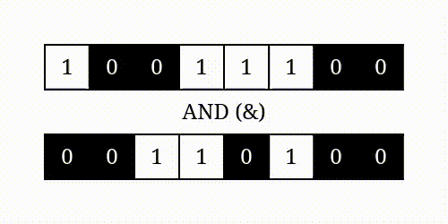

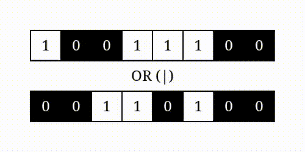

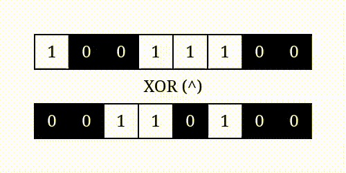

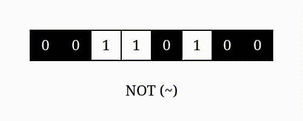

# **Python Kütüphaneleri (Modüller)**

Python'da standart olan (gömülü olan) modüller ile print(), input(), len() gibi fonksiyonları kullanmaktayız.  
Bunların haricinde python ile birlikte gelen ama gömülü olmayan yani kodlama esnasında içeri aktarmamız (import) gereken kütüphaneler de var. Bunlar 'math', 'random', 'time', 'os' 'turtle', 'tkinter' vb. kütüphanelerdir. [Tam listesi için buraya bakınız.](https://docs.python.org/3/py-modindex.html) Bunlar haricinde kullanılabilecek kütüphaneler için https://pypi.org/ sitesinden tarama yapabilirsiniz. Buradaki komutları sisteminizdeki komut isteminden çalıştırarak kütüphaneleri indirebilirsiniz. Şu an bu kısımda 'bazı' kütüphaneleri ele alacağız. Fakat konu ilerledikçe ilgili yeni kütüphaneleri de ele alacağız.  
**Kütüphaneler 3 farklı şekilde import edilebilir.**

1. from *kütüphane_adi* import *fonksiyon_adi* şeklinde
2. import *kütüphane_adi* şeklinde
3. import *kütüphane_adi* as *takma_ad* şeklinde

## Turtle Kütüphanesi

Öğretim amaçlı 2 Boyutlu çizim kütüphanesidir. Geometrik çizimler yapmamızı sağlayan fonksiyonları barındırır. import turtle veya from random turtle * olarak aktarılabilir.  
Varsayılan olarak turtle 0° (sağa dönük) ve kalem basılı olarak başlar. Not: Jupyter Notbeook ile kullanılınca son satıra turtle.done() yazılmalıdır yoksa her çalıştırmada hata alınır.

### Turtle Kütüphanesi ile Gelen Bazı Fonskiyonlar

- Bulunduğu derece yönüne doğru belirlenen pixel büyüklüğünde çizgi çizmek için **'turtle.forward()'** fonskiyonu kullanılır. Örnek: turtle.forward(100) (sağa doğru 100 pixel çizgi çizdi)
- Bulunduğu derecenin tersi yönüne doğru belirlenen pixel büyüklüğünde çizgi çizmek için **'turtle.backward()'** fonskiyonu kullanılır. Örnek: turtle.backward(100) (sola doğru 100 pixel çizgi çizdi)
- Bulunduğu dereceden belirlenen değerde sola döndürmek için **'turtle.left()'** fonskiyonu kullanılır.
- Bulunduğu dereceden belirlenen değerde sağa döndürmek için **'turtle.right()'** fonskiyonu kullanılır.
- Kalem kalınlığını değiştirmek için **'turtle.pensize()'** fonskiyonu kullanılır.
- Kalem rengini değiştirmek için **'turtle.color()'** fonskiyonu kullanılır.
- (Renkle) Doldurma işlemini başlatmak için **'turtle.begin_fill()'** fonskiyonu kullanılır. Parametresiz kullanılır. Kalem renginde doldurur.
- (Renkle) Doldurma işlemini bitirmek için **'turtle.end_fill()'** fonskiyonu kullanılır.
- Belirlenen yarıçap değerinde daire çizmek için **'turtle.circle()'** fonskiyonu kullanılır.
- Çizme hızını belirlemek için **'turtle.speed()'** fonskiyonu kullanılır.
- Kalemi kaldırmak (çizmemesi) için **'turtle.penup()'** fonskiyonu kullanılır.
- Kalemi bastırmak (çizmesi) için **'turtle.pendown()'** fonskiyonu kullanılır.
- Ekrandaki bir noktaya direkt hareket etmek için **'turtle.goto(x,y)'** fonskiyonu kullanılır. (setx, sety ve xcor, ycor fonksiyonları da var.)
- Ekranı temizlemek için **'turtle.clear()'** fonskiyonu kullanılır.
- Ekran boyutunu ayarlamak için **'turtle.screensize(canvwidth=genişlik, canvheight=yükseklik, bg="renk")'** fonskiyonu kullanılır. Örnek: turtle.screensize(canvwidth=400, canvheight=300, bg="blue")

**Etkinlik:** Türk bayrağındaki yıldızı turtle kütüphanesi ile çiziniz.

## Math Kütüphanesi

Standart olarak kullanamadığımız matematiksel fonksiyonları barındırır. import math veya from math import * olarak aktarılabilir.

### Math Kütüphanesi ile Gelen Matematiksel Bazı Fonskiyonlar

- Bir sayıyı aşağı yuvarlamak için **'math.ceil()'** fonskiyonu kullanılır.
- Bir sayıyı yukarı yuvarlamak için **'math.floor()'** fonskiyonu kullanılır.
- Bir sayının işaretini (+,-) başka bir sayıya aktarmak için **'math.copysign()'** fonskiyonu kullanılır. Örneğin math.copysign(5,-12) yazarsak sonuç -5 olur.
- Bir sayının float olarak mutlak değeri **'math.fabs()'** fonskiyonu ile alınır.
- Bir sayının faktöriyelini bulmak için **'math.factorial()'** fonskiyonu kullanılır.
- Bir sayının başka bir sayıya bölümünden kalanı flolat olarak bulmak için **'math.fmod()'** fonskiyonu kullanılır. Özellikle negatif sayılarda doğru sonuç verir.
- Flolat tipindeki sayıların toplamını bulmak için **'math.fsum()'** fonskiyonu kullanılır.
- Verilen sayıların EBOB'unu bulmak için **'math.gcd()'** fonskiyonu kullanılır. Örnek: math.gcd(sayi1,sayi2,sayi3)
- Pi sayısını kullanmak için **'math.pi()'** fonskiyonu kullanılır.
- Bir karekökünü bulmak için **'math.sqrt()'** fonskiyonu kullanılır.

**Etkinlik:** Kendi yaşınızı float olarak hesaplayıp (örn: (2022-2004)+5/12) yaşınızı aşağı ve yukarı yuvarlayınız.

**Etkinlik:** Evinizde yaşayanların yaşlarını float olarak hesaplayıp (örn: (2022-2004)+5/12) yaşları toplayınız.

**Etkinlik:** 7 sayısının faktöriyeli ile 4 sayısının faktöriyelinin EBOB'unu bulunuz.

**Etkinlik:** Bir çemberin çevresi 2*Pi sayısı*Çemberin Yarıçapıdır. Buna göre yarıçapı 19.23 olan çemberin çevresini hesaplayınız.

**Etkinlik:** Cumhuriyetimizin yaşının karekökünü bulunuz.

## Random Kütüphanesi

Rassalık (rasgele) işlemlerini yapmamızı sağlayan fonksiyonları barındırır. import random veya from random import * olarak aktarılabilir.

### Random Kütüphanesi ile Gelen Bazı Fonskiyonlar

- 0 ile 1 arasında rasgele bir sayı (float) üretmek için **'random.random()'** fonskiyonu kullanılır.
- Bir aralıkta rasgele bir sayı (float) üretmek için **'random.uniform()'** fonskiyonu kullanılır. Örnek: random.uniform(1,20)
- Bir aralıkta rasgele integer bir sayı üretmek için **'random.randint()'** fonskiyonu kullanılır. Örneğin random.randint(1,100) ile 1 ile 100 sayıları arasında rasgele bir sayı üretilir.
- Bir aralıkta rasgele integer bir sayı üretmek için **'random.randrange()'** fonskiyonu kullanılır. randint()'ten farkı, aralıkta belirli bir artış vererek rassal sayı ihtimalini biçimlendiririz. Örneğin random.randrange(0,100,5) ile 0 ile 100 sayıları arasında 0'dan başlayarak 5'er 5'er artan sayılardan rasgele bir sayı üretilir.
- Bir listedeki elemanları rasgele karıştırmak için **'random.shuffle()'** fonskiyonu kullanılır. Örnek random.shuffle(liste_adi)
- Bir listedeki elemanlardan rasgele birini seçmek için **'random.choice()'** fonskiyonu kullanılır. Örnek random.choice(liste_adi)
- Bir listedeki elemanlardan rasgele birkaçını seçmek için **'random.sample()'** fonskiyonu kullanılır. Örnek random.choice(liste_adi,secilecek_eleman_sayisi)

**Etkinlik:** Art arda 5 tane 1 ile 20 arasında rassal tam sayı oluşturunuz.

**Etkinlik:** 1 ile 50 arasında sadece çift sayılardan rassal tam sayı oluşturunuz.

**Etkinlik:** 0 ile 100 arasında sadece 13'ün katlarından rassal tam sayı oluşturunuz.

**Etkinlik:** Rasgele float oluşturduğunuz negatif bir sayıdan o sayının tam kısmını çıkararak -1'den büyük 0'dan küçük bir rasgele sayı oluşturunuz.

**Etkinlik:** Taş kağıt makas oyunu için oluşturulan liste tipi değişkenden makinenin seçimini rassal bir şekilde ekrana yazdırınız.

**Etkinlik:** Bir market müşterilerinin TC No ve alışveriş tutarlarını sözlük tipinde bir değişkenle tutmaktadır. Market 250 TL ve üzeri alışveriş yapan müşterilerinden rasgele 3'üne 500TL'lik hediye çeki verecektir. Bu akışı gerçekleştiren kodları yazınız.

## Time ve Datetime Kütüphanesi

Süre (Saat, Saniye), Tarih (Gün, Ay, Yıl) vb. elemanlarla işlemler yapmamızı sağlayan fonksiyonları barındırır.  
import time veya from time import *ile import datetime veya from datetime import* olarak aktarılabilir.  
Python için zamanın başlangıç noktası (epoch: belirli, kesin tarih) 1 Ocak 1970 olarak belirlenmiştir.

### Time Kütüphanesi ile Gelen Bazı Fonskiyonlar

- 1 Ocak 1970 tarihinden itibaren geçen süre float tipinde saniye olarak **'time.time()'** fonskiyonu ile alınır.
- **'time.gmtime()'** fonksiyonu ile float tipinde saniye olarak verilen süreyi 1 Ocak 1970 tarihine ekler ve yıl, ay, gün, saat, dakika, saniye, haftanın günü, yılın günü ve dts olarak 9 farklı değerde çıktı verir. Boş bırakılırsa kodun çalıştığı andaki zamana göre hesap eder. Saat dilimi (GMT) 0 olarak hesaplanır.
- **'time.localtime()'** fonksiyonu ile sistemdeki saat-tarih bilgileri yıl, ay, gün, saat, saniye vb. olarak çıktı alınır.
- **'time.asctime()'** fonksiyonu ile "Haftanın Günü, Ay, Gün Sayısı, Saat:Dakika:Saniye, Yıl" olarak çıktı alınır. Parametre olarak sadece **gm.time() fonksiyonunun çıktısına uygun bir girdi alır.** Boş bırakılırsa çalıştığı andaki zaman-tarih alınır.
- **'time.ctime()'** fonksiyonu ile "Haftanın Günü, Ay, Gün Sayısı, Saat:Dakika:Saniye, Yıl" olarak çıktı alınır. Parametre olarak **saniye cinsinden float/integer değer girilir.** Boş bırakılırsa çalıştığı andaki zaman-tarih alınır.
- **'time.sleep()'** fonksiyonu ile "bekle" blokları gibi kodların çalışmasını istediğimiz sürede durdururuz. Örnek: time.sleep(2) 'devamındaki kodu çalıştırmadan önce 2 saniye bekler.
- **'time.strftime()'** fonksiyonu ile asctime() fonksiyonuna ait bilgileri parçalayarak elde edebiliriz. Örneğin: print(time.strftime(%A)) ile haftanın tam gün adını (Sunday, Monday vb.) alırız. Bu fonksiyonun parametreleri:
  - **'time.strftime(%a)'** Hafta Günü Kısaltılmış
  - **'time.strftime(%A)'** Hafta Gün Tam Adı
  - **'time.strftime(%b)'** Ayın Kısaltılmış Adı
  - **'time.strftime(%B)'** Ayın Tam Adı
  - **'time.strftime(%c)'** Tam Tarih, Saat Ve Zaman Bilgisi
  - **'time.strftime(%d)'** Sayısal Olarak Gün
  - **'time.strftime(%j)'** Yılın Kaçıncı Günü Olduğu
  - **'time.strftime(%m)'** Sayısal Olarak Ay
  - **'time.strftime(%U)'** Kaçıncı Hafta Olduğu
  - **'time.strftime(%y)'** Yılın Son İki Rakamı
  - **'time.strftime(%Y)'** Yılın Dört Haneli Tam Hali
  - **'time.strftime(%x)'** Tam Tarih Bilgisi
  - **'time.strftime(%X)'** Tam Saat Bilgisi

### Datetime Kütüphanesi ile Gelen Bazı Fonskiyonlar

- **'datetime.date(yyyy,aa,gg)'** fonskiyonu ile girilen değerler ISO formatında tarihi elde edilir. Sistemdeki günü almak için **'datetime.date.today()'** metodu da vardır.
- **'datetime.time(saat,dakika,saniye,milisaniye)'** fonksiyonu ile girilen değerler parametrede görülen formatta zaman elde edilir. Bu parametreler tamamen girilmek zorunda değildir. Sadece dakika belirlemek datetime.time(minute=5) gibi 5 dakika tanımlayabilirsiniz:
  - Saat: hour, dakika: minute, saniye: second, milisaniye: microsecond olarak kodlanır.
- **'datetime.datetime(yyyy,aa,gg)'** fonskiyonu ile tarih (date) ve saat (time) birlikte olarak elde edilir. Ayrıca sonunda milisaniye (microsaniye) değeri de bulunur.
- **'datetime.timedelta()'** fonksiyonu ile tarih işlemleri (ekleme vb.) yapılır. Örneğin bir tarih tipinde değişkene 2 gün eklemek için: ekleme=tarih+datetime.timedelta(days=2) yazılır.
  - Gün: days, Saat: hours, Dakika: minutes, Saniye: seconds olarak kodlanır.
- **'datetime.date.weekday()'** fonksiyonu ile parametre olarak girilen değerin haftanın günü cinsinden çıktısı verilir. Örneğin: datetime.date.weekday(now) Not: **strftime** fonksiyonu datetime kütüphanesinin time ve date fonksiyonları için de kullanılır.

**Etkinlik:** Doğum tarihinizi bir tarih tipi değişken olarak girdikten sonra doğum tarihinizden bugüne kaç saniye geçmiş hesaplayınız.

**Etkinlik:** Doğum tarihinizi bir tarih tipi değişken olarak girdikten sonra o gün haftanın hangi günü imiş, bulunuz.

Burada yazılanların haricinde python ile otomatik olarak gelen birçok kütüphane vardır. [Bunların listesi için buraya tıklayınız.](https://docs.python.org/3/py-modindex.html#)  
Otomatik gelen kütüphaneler haricinde python topluluğu tarafından hazırlanmış ve yüklendikten sonra kullanılabilir kütüphaneler de vardır. Yapay zeka, makine öğrenmesi, 2D oyun, web sitesi frameworkleri gibi birçok alanda kütüphane vardır. [Bu kütüphanelerin listesi için buraya tıklayınız.](https://pypi.org/)

# **Karar Yapısı**

Tüm programlama dillerinde karar yapısı ile belirli bir koşulun gerçekleşmesi veya gerçekleşmemesi durumunda yapılacak işlemler sıralanır. Tüm dillerde temel karar yapısı "if" bloğudur.

## IF Yapısı

**"if" kelime olarak "eğer" anlamına gelmektedir. "Eğer şart gerçekleşirse (doğruysa-True) veya gerçekleşmezse (yanlışsa-False)" şeklinde çalışır.** Koşul yapıları boolean veri tipi ile çalışır. Şart gerçekleşmişse True, gerçekleşmemişse False değeri kabul eder ve koşula göre işlem bloğuna gider. **"if" kullanılan ifadenin sonuna ":" işareti getirilmezse blok çalışmaz, program hata verir.**

```python
ates = 39
if ates>37.5: print("Ateş Yüksek") #ateş 39 olduğu için bu print çalışır.
if ates<=37.5: print("Ateş Normal") #ateş 39 olduğu için bu print çalışmaz.
```

Eğer "if" ifadesinden sonra bir satırdan daha fazla kod yazılacaksa alt satırdan başlayarak sıralanır. Örnek:

```python
ates = 39
durum = "Düşük"
if ates>37.5:
    durum="Yüksek"
    print("Ateşiniz: ",durum)
if ates<=37.5:
    durum="Düşük"
    print("Ateşiniz: ",durum)
```

## ELSE Yapısı

Koşul yapısı olan if kullanılırken eğer ortada 2 ihtimal var ise tekrar if bloğu ile şart yazmaya gerek yoktur. Bunun için **else** bloğu kullanılır. **Else 'Değilse' anlamına gelir.** Örnek:

```python
ates = 39
if ates>37.5: print("Ateş Yüksek")
else: print("Ateş Normal") #else bloğu

durum = "Düşük"
if ates>37.5:
    durum="Yüksek"
    print("Ateşiniz: ",durum)
else:                                 #else bloğu
    durum="Düşük"
    print("Ateşiniz: ",durum)
```

## ELIF Yapısı

Eğer if kullanırken ortada 2 ihtimalden daha fazla ihtimal varsa **'elif'** (eğer değilse) kullanımı ile şartlar birbirine bağlanır. 'elif' ile **bir şartın gerçekleşmediği durumda diğer şarta bakar, gerçekleştiği durumda bakmaz.** Örnek:

```python
ates = 39
durum = "Düşük"
if ates>37.5:
    durum="Yüksek"
    print("Ateşiniz: ",durum)
elif ates<=35:                 #elif bloğu, öncesindeki şartın gerçkleşmediği durumda çalışır.
    durum="Düşük"
    print("Ateşiniz: ",durum)
else:
    durum="Orta"
    print("Ateşiniz: ",durum)
```

```python
#Yukarıdaki örneği elif ile yapmazsak mantıksal karşılaştırma ile yapabiliriz.
ates = 39
durum = "Düşük"
if ates>37.5:
    durum="Yüksek"
    print("Ateşiniz: ",durum)
if ates<=35:
    durum="Düşük"
    print("Ateşiniz: ",durum)
if ates>35 and ates<=37.5:      #and işleci
    durum="Orta"
    print("Ateşiniz: ",durum)
```

```python
#Art arda birçok elif kullanılabilir.
puan = 73
if puan>=0 and puan<45: print("Zayıf")
elif puan>=0 and puan<55: print("Geçer")
elif puan>=0 and puan<70: print("Orta")
elif puan>=0 and puan<85: print("İyi")
elif puan>=0 and puan<=100: print("Pekiyi") #son blokta else kullanmadık çünkü 100'den büyük not girilince "pekiyi" yazmaması gerekir.
else: print("Lütfen 0-100 arasında not giriniz!")
```

Yukarıdaki örneği elif değil if ile yaparsanız elif'in önemini anlamış olursunuz.

**Etkinlik:** Gelir düzeyine göre 'düşük', 'orta' ve 'yüksek' olarak sınıflama yapan bir algoritma kodlayınız. (Gelir 9000'den az ise düşük, 9000 ile 17000 arasında ise orta, 17000'dan fazla ise yüksek olarak baz alınmalıdır.)

İç İçe If kullanılabilir. Koşul içine koşul eklenebilir. Unutulmaması gereken bir üst düzeydeki koşulu gerçekleşmesine bağlı olarak gerçekleşir.

```python
if puan>=0 and puan<=100:
    if puan<45: print("Zayıf")
    elif puan<55: print("Geçer")
    elif puan<70: print("Orta")
    elif puan<85: print("İyi")
    else puan<=100: print("Pekiyi")
else: print("Lütfen 0-100 arasında not giriniz!")
```

**Etkinlik:** Kullanıcıya belirti soruları sorarak [Covid-Nezle-Grip-Aleri Tablosuna](https://orduism.saglik.gov.tr/Resim/317391/0/kovid-resimjpg.png) göre teşhis edip sonucu ekrana yazdırınız.

İf yapısı string, integer, float, boolean, list gibi veri tiplerinde de kullanılabilir. Örnekler:

```python
sifre = input("Şifre Giriniz: ")
sifreTekrar = input("Şifrenizi Tekrar Giriniz: ")
if sifre == sifreTekrar: print("Şifre onaylandı.")
if sifre != sifreTekrar: print("Şifreleri aynı giriniz.")
```

```python
yas = int(input("Lütfen yaşınızı giriniz: "))
if not yas>=11: print("Bu oyunu oynayamazsınız.") #eğerdeğilse kalıbını kullandık.
else: print("Bu oyun için uygun yaştasınız, yönlendiriliyorsunuz...")
```

```python
yas = int(input("Lütfen yaşınızı giriniz: "))
sonuc = yas>=11 #burada sonuc true veya false boolean tipi bir değer alır.
print(sonuc)
if sonuc: print("Bu oyun için uygun yaştasınız, yönlendiriliyorsunuz...")
else: print("Bu oyunu oynayamazsınız.")
```

```python
i = int(input("0'dan 9'a kadar bir rakam yazınız."))
liste = [0,1,2,3,4,5,6,7,8,9]
if i in liste: print(i," sayısını girdiniz.")
else: print("0-9 arasında bir sayı girmediniz.")
```

```python
ePosta = input("e-Posta Adresinizi Giriniz: ")
if not "@" in list(ePosta):
    print("E-posta adresinde @ işareti olmak zorundadır.")
```

## İç İçe IF Yapısı (Nested Yapılar)

Genellikle dallanma veya ön şartlar gerektiren durumlarda kullanılır. Örneğin öğrencinin notu girilirken 0 ile 100 arasında ise geçerli bir puanı vardır ve bu puanlar arasında "Pekiyi - Zayıf" olarak değerlendirmeler alır. Fakat notu 0 ile 100 arasında değilse bu not geçerli değildir. Burada unutulmaması gereken ilk if bloğunun şartı gerçekleşmezse içerideki if bloklarının çalışmayacak olmasıdır.

```python
#nested if yapısı
yas=int(input("Yaşınızı Giriniz: "))
if yas>=1 and yas<=17:
    if yas>=6:
        if yas<=11: print("Tahminen ilkokul öğrencisidir.")
        if yas<=14 and yas>11: print("Tahminen Ortaokul öğrencisidir.")
        if yas>14: print("Tahminen Lise öğrencisidir.")
    else:
        if yas>=4: print("Tahminen Anaokulu öğrencisidir.")
        else: print("Okula veya anaokuluna başlama çağı gelmemiştir.")
else: print("Okul çağı bitmiş bir öğrencidir. Üniversiteye gidiyor olabilir.")
```

**Etkinlik:** Kullanıcıya belirti soruları sorarak [Covid-Nezle-Grip-Aleri Tablosuna](https://orduism.saglik.gov.tr/Resim/317391/0/kovid-resimjpg.png) göre teşhis edip sonucu ekrana yazdırınız. Nested yapı kullanınız.

```python
#Örnek problemin çözümü
kuladi = "abcd@gmail.com"
sifre = "12345"
girilen_kuladi = input("Kullanıcı Adınızı Giriniz: ")
girilen_sifre = input("Şifrenizi Giriniz: ")

if kuladi == girilen_kuladi and sifre == girilen_sifre:
    print ("Giriş Başarılı")
else:
    print ("Yanlış Kullanıcı Adı veya Şifre")

#Örnek problemin farklı (nested) çözümü
kuladi = "abcd@gmail.com"
sifre = "12345"
girilen_kuladi = input("Kullanıcı Adınızı Giriniz: ")

if kuladi != girilen_kuladi:
    print ("Böyle bir kullanıcımız bulunmamaktadır.")
else:
    girilen_sifre = input("Şifrenizi Giriniz: ")
    if sifre != girilen_sifre:
        print ("Yanlış Şifre Girdiniz. Tekrar baştan deneyiniz.")
    else:
        print ("Giriş Başarılı.")
```